# Bellabeat Case Study

Publisher: Jackie Lo

Last Update: 2021-07-28

# **Bellabeat Marketing Stragey/Analysis**

## Project Introduction

This project contains one of two case studies of Google’s Data Analytics Professional Certification provided by Google. The requirements for the case study are for the analyst to do data analysis using FitBit Fitness Tracker data to provide high-level marketing strategy recommendations for Bellabeat through the process of Ask, Prepare, Process, Analyst, Share, and Act process.

Bellabeat is a high-tech company that manufactures health-focused innovative products like an app, Leaf (bracelet), Time (watch), and Spring (water bottle). The company also provides subscription services or membership programs for users to have 24/7 access to their fully personalized guidance on nutrition, activity, sleep, health and beauty, and mindfulness-based on their lifestyle and goals.

## Business Task

Bellabeat, being a successful small tech company, can become a prominent player in the global smart device market, with smart devices becoming a big part of people’s lives. Bellabeat will significantly benefit from the insight of smart devices usage trends to make data-driven decisions for growth and opportunities.

The project goal is to find out how to apply appropriate marketing strategies for Bellabeat’s wellness smart devices by analyzing the usage of non-Bellabeat devices. Then, find user’s key patterns and relationships, and trends with a final deliverable of high-level marketing recommendations based on critical findings.

### *Objective*

- What are some trends in smart device usage?
- How could these trends apply to Bellabeat customers?
- How could these trends help influence Baellabeat marketing strategy?

## Prepare and Process

Where is the data stored?

- The data being used is the Fitbit Fitness Tracker Data (CC0: Public Domain, data set made available through Mobius) stored on Kaggle.

How is the data organized? Is it in long or wide format?

- The 18 data sets that are provided are organized in both long and wide format as a .csv file. The long-formatted data sets will be primarily used.

Are there issues with bias or credibility in this data? Does your data ROCCC (Reliable, Original, Comprehensive, Current, Cited)?

How are you addressing licensing, privacy, security, and accessibility?

How did you verify the data’s integrity? * We will be using R programming to check and change if needed for unique ID

*Import library needed:*

```r
#install.packages("tidyverse")
#install.packages("ids")
#install.packages("gridExtra")
library(tidyverse)
library(lubridate)
library(skimr)
library(janitor)
library(ids)
library(gridExtra)
```

### CSV files being used:

- dailyActivity_merged.csv
- heartrate_seconds_merged.csv
- sleepDay_merged.csv
- weightLogInfo_merged.csv
- 25.csv
- ACTIVITY_1599810432505.csv
- SLEEP_1599810433552.csv
- HEARTRATE_AUTO_1599810433761.csv

*Importing/Read .csv datasets into dataframes:*

```r
daily_activity = read.csv("~/Case_Study_bellabeat/Fitabase Data 4.12.16-5.12.16/dailyActivity_merged.csv")
heart_rate_seconds = read.csv("~/Case_Study_bellabeat/Fitabase Data 4.12.16-5.12.16/heartrate_seconds_merged.csv")
sleep_day = read.csv("~/Case_Study_bellabeat/Fitabase Data 4.12.16-5.12.16/sleepDay_merged.csv")
weight_log = read.csv("~/Case_Study_bellabeat/Fitabase Data 4.12.16-5.12.16/weightLogInfo_merged.csv")
fitness_trend = read.csv("~/Case_Study_bellabeat/25.csv")
activity_log = read.csv("~/Case_Study_bellabeat/ACTIVITY/ACTIVITY_1599810432505.csv")
sleep_log = read.csv("~/Case_Study_bellabeat/SLEEP/SLEEP_1599810433552.csv")
heartrate_auto_log = read.csv("~/Case_Study_bellabeat/HEARTRATE_AUTO/HEARTRATE_AUTO_1599810433761.csv")
```

### **Processing/checking Heart Rate Data set**

```r
#checking data quality of the original
head(heart_rate_seconds)
```

```
##           Id                 Time Value
## 1 2022484408 4/12/2016 7:21:00 AM    97
## 2 2022484408 4/12/2016 7:21:05 AM   102
## 3 2022484408 4/12/2016 7:21:10 AM   105
## 4 2022484408 4/12/2016 7:21:20 AM   103
## 5 2022484408 4/12/2016 7:21:25 AM   101
## 6 2022484408 4/12/2016 7:22:05 AM    95
```

```r
skim_without_charts(heart_rate_seconds)
```

Data summary

| Name | heart_rate_seconds |
| --- | --- |
| Number of rows | 2483658 |
| Number of columns | 3 |
| _______________________ |  |
| Column type frequency: |  |
| character | 1 |
| numeric | 2 |
| ________________________ |  |
| Group variables | None |

**Variable type: character**

| skim_variable | n_missing | complete_rate | min | max | empty | n_unique | whitespace |
| --- | --- | --- | --- | --- | --- | --- | --- |
| Time | 0 | 1 | 19 | 21 | 0 | 961274 | 0 |

**Variable type: numeric**

| skim_variable | n_missing | complete_rate | mean | sd | p0 | p25 | p50 | p75 | p100 |
| --- | --- | --- | --- | --- | --- | --- | --- | --- | --- |
| Id | 0 | 1 | 5.513765e+09 | 1950223761.0 | 2022484408 | 4388161847 | 5553957443 | 6962181067 | 8877689391 |
| Value | 0 | 1 | 7.733000e+01 | 19.4 | 36 | 63 | 73 | 88 | 203 |

```r
anyNA(heart_rate_seconds)
```

```
## [1] FALSE
```

```r
anyDuplicated(heart_rate_seconds)
```

```
## [1] 0
```

```r
#cleaning/confirming data for quality to be place in a dataset that will be used for analysis
heart_rate_sec = heart_rate_seconds %>%
  clean_names() %>%
  distinct() %>%
  mutate(time = parse_date_time(time, "%m/%d/%Y %I:%M:%S %p")) %>%
  separate(col = time,
           into = c("date", "time"), sep = " ") %>%
  mutate(date = as.Date(date),
         time = format(strptime(time, "%H:%M:%S"), "%H")) %>%
  rename(heart_rate = value) %>%
  group_by(id, date, time) %>%
  summarize(heart_rate = mean(heart_rate)) %>%
  arrange(id, date, time)
#final quality check
head(heart_rate_sec)
```

```
## # A tibble: 6 x 4
## # Groups:   id, date [1]
##           id date       time  heart_rate
##        <dbl> <date>     <chr>      <dbl>
## 1 2022484408 2016-04-12 07          83.2
## 2 2022484408 2016-04-12 08          68.6
## 3 2022484408 2016-04-12 09          66.4
## 4 2022484408 2016-04-12 10         107.
## 5 2022484408 2016-04-12 11          67.8
## 6 2022484408 2016-04-12 12          66.2
```

```r
anyNA(heart_rate_sec)
```

```
## [1] FALSE
```

```r
anyDuplicated(heart_rate_sec)
```

```
## [1] 0
```

```r
#checking the second heart rate data for quality of the original
head(heartrate_auto_log)
```

```
##      ï..date  time heartRate
## 1 2019-09-13 06:53        80
## 2 2019-09-13 07:23        65
## 3 2019-09-13 09:53        51
## 4 2019-09-13 10:53        87
## 5 2019-09-13 11:23        60
## 6 2019-09-13 12:23        56
```

```r
skim_without_charts(heartrate_auto_log)
```

Data summary

| Name | heartrate_auto_log |
| --- | --- |
| Number of rows | 2430 |
| Number of columns | 3 |
| _______________________ |  |
| Column type frequency: |  |
| character | 2 |
| numeric | 1 |
| ________________________ |  |
| Group variables | None |

**Variable type: character**

| skim_variable | n_missing | complete_rate | min | max | empty | n_unique | whitespace |
| --- | --- | --- | --- | --- | --- | --- | --- |
| ï..date | 0 | 1 | 10 | 10 | 0 | 91 | 0 |
| time | 0 | 1 | 5 | 5 | 0 | 1023 | 0 |

**Variable type: numeric**

| skim_variable | n_missing | complete_rate | mean | sd | p0 | p25 | p50 | p75 | p100 |
| --- | --- | --- | --- | --- | --- | --- | --- | --- | --- |
| heartRate | 0 | 1 | 68.61 | 20.92 | 47 | 54 | 62 | 77 | 150 |

```r
anyNA(heartrate_auto_log)
```

```
## [1] FALSE
```

```r
anyDuplicated(heartrate_auto_log)
```

```
## [1] 0
```

```r
#random id generator
set.seed(2430)
activity_id = sort(sample.int(2430,2430))

#cleaning/confirming data for quality to be place in a data set that will be used for analysis
heartrate_auto = heartrate_auto_log %>%
  clean_names() %>%
  distinct() %>%
  rename(date = i_date) %>%
  mutate(date = as.Date(date, "%Y-%m-%d"),
         time = substr(time, 1, 5),
         id = activity_id) %>%
  arrange(id, date, time)

#final quality check
head(heartrate_auto)
```

```
##         date  time heart_rate id
## 1 2019-09-13 06:53         80  1
## 2 2019-09-13 07:23         65  2
## 3 2019-09-13 09:53         51  3
## 4 2019-09-13 10:53         87  4
## 5 2019-09-13 11:23         60  5
## 6 2019-09-13 12:23         56  6
```

```r
anyNA(heartrate_auto)
```

```
## [1] FALSE
```

```r
anyDuplicated(heartrate_auto)
```

```
## [1] 0
```

### **Processing/checking Sleep Data set**

```r
#checking data quality of the original
head(sleep_day)
```

```
##           Id              SleepDay TotalSleepRecords TotalMinutesAsleep
## 1 1503960366 4/12/2016 12:00:00 AM                 1                327
## 2 1503960366 4/13/2016 12:00:00 AM                 2                384
## 3 1503960366 4/15/2016 12:00:00 AM                 1                412
## 4 1503960366 4/16/2016 12:00:00 AM                 2                340
## 5 1503960366 4/17/2016 12:00:00 AM                 1                700
## 6 1503960366 4/19/2016 12:00:00 AM                 1                304
##   TotalTimeInBed
## 1            346
## 2            407
## 3            442
## 4            367
## 5            712
## 6            320
```

```r
skim_without_charts(sleep_day)
```

Data summary

| Name | sleep_day |
| --- | --- |
| Number of rows | 413 |
| Number of columns | 5 |
| _______________________ |  |
| Column type frequency: |  |
| character | 1 |
| numeric | 4 |
| ________________________ |  |
| Group variables | None |

**Variable type: character**

| skim_variable | n_missing | complete_rate | min | max | empty | n_unique | whitespace |
| --- | --- | --- | --- | --- | --- | --- | --- |
| SleepDay | 0 | 1 | 20 | 21 | 0 | 31 | 0 |

**Variable type: numeric**

| skim_variable | n_missing | complete_rate | mean | sd | p0 | p25 | p50 | p75 | p100 |
| --- | --- | --- | --- | --- | --- | --- | --- | --- | --- |
| Id | 0 | 1 | 5.000979e+09 | 2.06036e+09 | 1503960366 | 3977333714 | 4702921684 | 6962181067 | 8792009665 |
| TotalSleepRecords | 0 | 1 | 1.120000e+00 | 3.50000e-01 | 1 | 1 | 1 | 1 | 3 |
| TotalMinutesAsleep | 0 | 1 | 4.194700e+02 | 1.18340e+02 | 58 | 361 | 433 | 490 | 796 |
| TotalTimeInBed | 0 | 1 | 4.586400e+02 | 1.27100e+02 | 61 | 403 | 463 | 526 | 961 |

```r
anyNA(sleep_day)
```

```
## [1] FALSE
```

```r
anyDuplicated(sleep_day)
```

```
## [1] 162
```

```r
#cleaning/confirming data for quality to be place in a data set that will be used for analysis
sleep_d = sleep_day %>%
  distinct() %>%
  clean_names() %>%
  separate(col = sleep_day,
           into = c("sleep_day", "sleep_time"), sep = " ") %>%
  mutate(sleep_day = as.Date(sleep_day,"%m/%d/%Y")) %>%
  rename(date = sleep_day) %>%
  mutate(time_awake = total_time_in_bed - total_minutes_asleep) %>%
  arrange(id,date) %>%
  select(-total_sleep_records, -sleep_time)

#final quality check
head(sleep_d)
```

```
##           id       date total_minutes_asleep total_time_in_bed time_awake
## 1 1503960366 2016-04-12                  327               346         19
## 2 1503960366 2016-04-13                  384               407         23
## 3 1503960366 2016-04-15                  412               442         30
## 4 1503960366 2016-04-16                  340               367         27
## 5 1503960366 2016-04-17                  700               712         12
## 6 1503960366 2016-04-19                  304               320         16
```

```r
anyNA(sleep_d)
```

```
## [1] FALSE
```

```r
anyDuplicated(sleep_d)
```

```
## [1] 0
```

```r
#checking the second sleep data for quality of the original
head(sleep_log)
```

```
##      ï..date lastSyncTime deepSleepTime shallowSleepTime wakeTime      start
## 1 2018-09-29   1538285362             0                0        0 1538245800
## 2 2018-09-30   1538396903           141              253        2 1538255880
## 3 2018-10-01   1539148718             0                0        0 1538418600
## 4 2018-10-02   1539148718            80               49        0 1538418180
## 5 2018-10-03   1539148718             0                0        0 1538591400
## 6 2018-10-04   1539148718             0                0        0 1538677800
##         stop
## 1 1538245800
## 2 1538279640
## 3 1538418600
## 4 1538425920
## 5 1538591400
## 6 1538677800
```

```r
skim_without_charts(sleep_log)
```

Data summary

| Name | sleep_log |
| --- | --- |
| Number of rows | 538 |
| Number of columns | 7 |
| _______________________ |  |
| Column type frequency: |  |
| character | 1 |
| numeric | 6 |
| ________________________ |  |
| Group variables | None |

**Variable type: character**

| skim_variable | n_missing | complete_rate | min | max | empty | n_unique | whitespace |
| --- | --- | --- | --- | --- | --- | --- | --- |
| ï..date | 0 | 1 | 10 | 10 | 0 | 269 | 0 |

**Variable type: numeric**

| skim_variable | n_missing | complete_rate | mean | sd | p0 | p25 | p50 | p75 | p100 |
| --- | --- | --- | --- | --- | --- | --- | --- | --- | --- |
| lastSyncTime | 0 | 1 | 1.558860e+09 | 12263513.76 | 1538285362 | 1550407001 | 1565672299 | 1569240513 | 1574058669 |
| deepSleepTime | 0 | 1 | 1.559000e+01 | 76.66 | 0 | 0 | 0 | 0 | 827 |
| shallowSleepTime | 0 | 1 | 2.371000e+01 | 94.97 | 0 | 0 | 0 | 0 | 878 |
| wakeTime | 0 | 1 | 1.000000e-02 | 0.12 | 0 | 0 | 0 | 0 | 2 |
| start | 0 | 1 | 1.557395e+09 | 12180772.36 | 1538245800 | 1546194600 | 1562351400 | 1568313000 | 1574015400 |
| stop | 0 | 1 | 1.557397e+09 | 12181880.96 | 1538245800 | 1546194600 | 1562351400 | 1568313000 | 1574058660 |

```r
anyNA(sleep_log)
```

```
## [1] FALSE
```

```r
anyDuplicated(sleep_log)
```

```
## [1] 270
```

```r
#random id generator
set.seed(269)
sleep_id = sort(sample.int(269,269))

#cleaning/confirming data for quality to be place in a dataset that will be used for analysis
sleep_l = sleep_log %>%
  distinct() %>%
  clean_names() %>%
  rename(date = i_date,
         time_awake = wake_time) %>%
  mutate(date = as.Date(date, "%Y-%m-%d"), id = sleep_id,
         total_minutes_asleep = deep_sleep_time + shallow_sleep_time,
         total_time_in_bed = total_minutes_asleep + time_awake) %>%
  select(id, date, total_minutes_asleep,
         total_time_in_bed, time_awake) %>%
  arrange(id, date)

#final quality check
head(sleep_l)
```

```
##   id       date total_minutes_asleep total_time_in_bed time_awake
## 1  1 2018-09-29                    0                 0          0
## 2  2 2018-09-30                  394               396          2
## 3  3 2018-10-01                    0                 0          0
## 4  4 2018-10-02                  129               129          0
## 5  5 2018-10-03                    0                 0          0
## 6  6 2018-10-04                    0                 0          0
```

```r
anyNA(sleep_l)
```

```
## [1] FALSE
```

```r
anyDuplicated(sleep_l)
```

```
## [1] 0
```

### **Processing/checking Weight Log Data set**

```r
#checking data quality of the original
head(weight_log)
```

```
##           Id                  Date WeightKg WeightPounds Fat   BMI
## 1 1503960366  5/2/2016 11:59:59 PM     52.6     115.9631  22 22.65
## 2 1503960366  5/3/2016 11:59:59 PM     52.6     115.9631  NA 22.65
## 3 1927972279  4/13/2016 1:08:52 AM    133.5     294.3171  NA 47.54
## 4 2873212765 4/21/2016 11:59:59 PM     56.7     125.0021  NA 21.45
## 5 2873212765 5/12/2016 11:59:59 PM     57.3     126.3249  NA 21.69
## 6 4319703577 4/17/2016 11:59:59 PM     72.4     159.6147  25 27.45
##   IsManualReport        LogId
## 1           True 1.462234e+12
## 2           True 1.462320e+12
## 3          False 1.460510e+12
## 4           True 1.461283e+12
## 5           True 1.463098e+12
## 6           True 1.460938e+12
```

```r
anyNA(weight_log)
```

```
## [1] TRUE
```

```r
anyDuplicated(weight_log)
```

```
## [1] 0
```

```r
#cleaning/confirming data for quality to be place in a dataset that will be used for analysis
weight_l = weight_log %>%
  distinct() %>%
  clean_names() %>%
  mutate(date = as.Date(date, "%m/%d/%Y"), height = sqrt(weight_kg/bmi)*100) %>%
  select(-weight_pounds, -log_id, -is_manual_report, -fat) %>%
  arrange(id, date)

#final quality check
head(weight_l)
```

```
##           id       date weight_kg   bmi   height
## 1 1503960366 2016-05-02      52.6 22.65 152.3908
## 2 1503960366 2016-05-03      52.6 22.65 152.3908
## 3 1927972279 2016-04-13     133.5 47.54 167.5757
## 4 2873212765 2016-04-21      56.7 21.45 162.5840
## 5 2873212765 2016-05-12      57.3 21.69 162.5352
## 6 4319703577 2016-04-17      72.4 27.45 162.4045
```

```r
anyNA(weight_l)
```

```
## [1] FALSE
```

```r
anyDuplicated(weight_l)
```

```
## [1] 0
```

### **Processing/checking Fitness Trend Data set**

```r
#checking data quality of the original
head(fitness_trend)
```

```
##         date step_count mood calories_burned hours_of_sleep bool_of_active
## 1 2017-10-06       5464  200             181              5              0
## 2 2017-10-07       6041  100             197              8              0
## 3 2017-10-08         25  100               0              5              0
## 4 2017-10-09       5461  100             174              4              0
## 5 2017-10-10       6915  200             223              5            500
## 6 2017-10-11       4545  100             149              6              0
##   weight_kg
## 1        66
## 2        66
## 3        66
## 4        66
## 5        66
## 6        66
```

```r
anyNA(fitness_trend)
```

```
## [1] FALSE
```

```r
anyDuplicated(fitness_trend)
```

```
## [1] 0
```

```r
#random id generator
set.seed(96)
fitness_id = sort(sample.int(96,96))

#cleaning/confirming data for quality to be place in a dataset that will be used for analysis
fitness_t = fitness_trend %>%
  distinct() %>%
  clean_names() %>%
  rename(total_minutes_asleep = hours_of_sleep, total_steps = step_count) %>%
  mutate(id = fitness_id,
         date = as.Date(date, "%Y-%m-%d"),
         total_minutes_asleep = total_minutes_asleep * 60) %>%
  select(-mood, -bool_of_active) %>%
  arrange(id, date)

fitness_sleep_trend = fitness_t %>%
  select(id, date, total_minutes_asleep)

fitness_weight_trend = fitness_t %>%
  select(id, date, weight_kg)

fitness_activity_trend = fitness_t %>%
  select(id, date, total_steps, calories_burned)

#final quality check
head(fitness_t)
```

```
##         date total_steps calories_burned total_minutes_asleep weight_kg id
## 1 2017-10-06        5464             181                  300        66  1
## 2 2017-10-07        6041             197                  480        66  2
## 3 2017-10-08          25               0                  300        66  3
## 4 2017-10-09        5461             174                  240        66  4
## 5 2017-10-10        6915             223                  300        66  5
## 6 2017-10-11        4545             149                  360        66  6
```

```r
head(fitness_activity_trend)
```

```
##   id       date total_steps calories_burned
## 1  1 2017-10-06        5464             181
## 2  2 2017-10-07        6041             197
## 3  3 2017-10-08          25               0
## 4  4 2017-10-09        5461             174
## 5  5 2017-10-10        6915             223
## 6  6 2017-10-11        4545             149
```

```r
head(fitness_sleep_trend)
```

```
##   id       date total_minutes_asleep
## 1  1 2017-10-06                  300
## 2  2 2017-10-07                  480
## 3  3 2017-10-08                  300
## 4  4 2017-10-09                  240
## 5  5 2017-10-10                  300
## 6  6 2017-10-11                  360
```

```r
head(fitness_weight_trend)
```

```
##   id       date weight_kg
## 1  1 2017-10-06        66
## 2  2 2017-10-07        66
## 3  3 2017-10-08        66
## 4  4 2017-10-09        66
## 5  5 2017-10-10        66
## 6  6 2017-10-11        66
```

```r
anyNA(fitness_t)
```

```
## [1] FALSE
```

```r
anyNA(fitness_activity_trend)
```

```
## [1] FALSE
```

```r
anyNA(fitness_sleep_trend)
```

```
## [1] FALSE
```

```r
anyNA(fitness_weight_trend)
```

```
## [1] FALSE
```

```r
anyDuplicated(fitness_t)
```

```
## [1] 0
```

```r
anyDuplicated(fitness_activity_trend)
```

```
## [1] 0
```

```r
anyDuplicated(fitness_sleep_trend)
```

```
## [1] 0
```

```r
anyDuplicated(fitness_weight_trend)
```

```
## [1] 0
```

### **Processing/checking Activities Data set**

```r
#checking data quality of the original
head(daily_activity)
```

```
##           Id ActivityDate TotalSteps TotalDistance TrackerDistance
## 1 1503960366    4/12/2016      13162          8.50            8.50
## 2 1503960366    4/13/2016      10735          6.97            6.97
## 3 1503960366    4/14/2016      10460          6.74            6.74
## 4 1503960366    4/15/2016       9762          6.28            6.28
## 5 1503960366    4/16/2016      12669          8.16            8.16
## 6 1503960366    4/17/2016       9705          6.48            6.48
##   LoggedActivitiesDistance VeryActiveDistance ModeratelyActiveDistance
## 1                        0               1.88                     0.55
## 2                        0               1.57                     0.69
## 3                        0               2.44                     0.40
## 4                        0               2.14                     1.26
## 5                        0               2.71                     0.41
## 6                        0               3.19                     0.78
##   LightActiveDistance SedentaryActiveDistance VeryActiveMinutes
## 1                6.06                       0                25
## 2                4.71                       0                21
## 3                3.91                       0                30
## 4                2.83                       0                29
## 5                5.04                       0                36
## 6                2.51                       0                38
##   FairlyActiveMinutes LightlyActiveMinutes SedentaryMinutes Calories
## 1                  13                  328              728     1985
## 2                  19                  217              776     1797
## 3                  11                  181             1218     1776
## 4                  34                  209              726     1745
## 5                  10                  221              773     1863
## 6                  20                  164              539     1728
```

```r
anyNA(daily_activity)
```

```
## [1] FALSE
```

```r
anyDuplicated(daily_activity)
```

```
## [1] 0
```

```r
#cleaning/confirming data for quality to be place in a dataset that will be used for analysis
activity_d = daily_activity %>%
  distinct() %>%
  clean_names() %>%
  rename(date = activity_date, calories_burned = calories) %>%
  mutate(date = as.Date(date, "%m/%d/%Y")) %>%
  #mutate(avg_active_min = fairly_active_minutes + lightly_active_minutes + sedentary_minutes +
                                 #very_active_minutes) %>%
  select(-tracker_distance, -logged_activities_distance, -moderately_active_distance,
         -light_active_distance, -sedentary_active_distance,
         -fairly_active_minutes, -lightly_active_minutes, -sedentary_minutes, -very_active_minutes) %>%
  arrange(id, date)

#final quality check
head(activity_d)
```

```
##           id       date total_steps total_distance very_active_distance
## 1 1503960366 2016-04-12       13162           8.50                 1.88
## 2 1503960366 2016-04-13       10735           6.97                 1.57
## 3 1503960366 2016-04-14       10460           6.74                 2.44
## 4 1503960366 2016-04-15        9762           6.28                 2.14
## 5 1503960366 2016-04-16       12669           8.16                 2.71
## 6 1503960366 2016-04-17        9705           6.48                 3.19
##   calories_burned
## 1            1985
## 2            1797
## 3            1776
## 4            1745
## 5            1863
## 6            1728
```

```r
anyNA(activity_d)
```

```
## [1] FALSE
```

```r
anyDuplicated(activity_d)
```

```
## [1] 0
```

```r
#checking the second Activity data for quality of the original
head(activity_log)
```

```
##      ï..date lastSyncTime steps distance runDistance calories
## 1 2018-09-29   1538285362  8017     5341          65      157
## 2 2018-09-30   1538396903  4002     2717         127       86
## 3 2018-10-01   1539148718  2379     1484         123       47
## 4 2018-10-02   1539148718     0        0           0        0
## 5 2018-10-03   1539148718  8051     5501         182      165
## 6 2018-10-04   1539148718  6504     4443         195      136
```

```r
anyNA(activity_log)
```

```
## [1] FALSE
```

```r
anyDuplicated(activity_log)
```

```
## [1] 270
```

```r
#generating random id number
set.seed(269)
activity_id = sort(sample.int(269, 269))

#cleaning/confirming data for quality to be place in a dataset that will be used for analysis
activity_l = activity_log %>%
  distinct() %>%
  clean_names() %>%
  rename(date = i_date, calories_burned = calories, very_active_distance = run_distance,
         total_steps = steps, total_distance = distance) %>%
  mutate(date = as.Date(date, "%Y-%m-%d"),
         total_distance = total_distance / 1000,
         very_active_distance = very_active_distance / 1000,
         id = c(activity_id)) %>%
  select(-last_sync_time) %>%
  arrange(id, date)

#final quality check
head(activity_l)
```

```
##         date total_steps total_distance very_active_distance calories_burned id
## 1 2018-09-29        8017          5.341                0.065             157  1
## 2 2018-09-30        4002          2.717                0.127              86  2
## 3 2018-10-01        2379          1.484                0.123              47  3
## 4 2018-10-02           0          0.000                0.000               0  4
## 5 2018-10-03        8051          5.501                0.182             165  5
## 6 2018-10-04        6504          4.443                0.195             136  6
```

```r
anyNA(activity_l)
```

```
## [1] FALSE
```

```r
anyDuplicated(activity_l)
```

```
## [1] 0
```

## Analyze & Share

*Binding all the data set together into activity, sleep, heartrate, weight*

```r
activity = bind_rows(activity_d, activity_l, fitness_activity_trend)
sleep = bind_rows(sleep_d, sleep_l, fitness_sleep_trend)
heartrate = rbind(heart_rate_sec, heartrate_auto)
weight = bind_rows(fitness_weight_trend, weight_l)
```

```r
paste("The number of unique IDs in Activity dataset =",n_unique(activity$id))
```

```
## [1] "The number of unique IDs in Activity dataset = 302"
```

```r
paste("The number of unique IDs in Sleep dataset =", n_unique(sleep$id))
```

```
## [1] "The number of unique IDs in Sleep dataset = 293"
```

```r
paste("The number of unique IDs in Heartrate dataset =", n_unique(heartrate$id))
```

```
## [1] "The number of unique IDs in Heartrate dataset = 2444"
```

```r
paste("The number of unique IDs in Weight dataset =", n_unique(weight$id))
```

```
## [1] "The number of unique IDs in Weight dataset = 104"
```

### **Visualization**

*Calories Burned by Total Number of Steps and Total Distance*

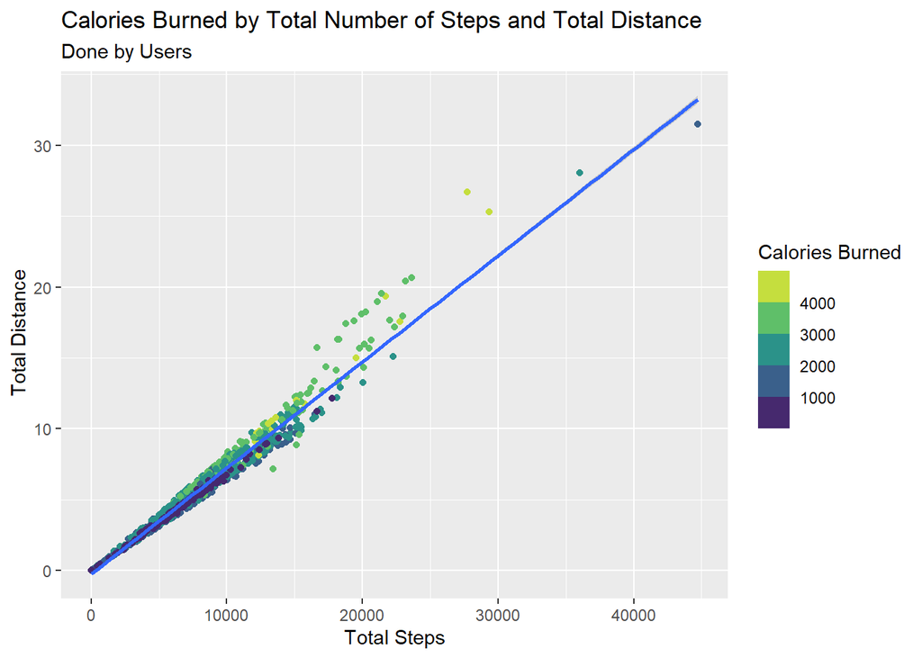

```r
ggplot(activity, aes(total_steps, total_distance))+
  geom_jitter() +
  geom_point(aes(color = calories_burned)) +
  scale_color_viridis_b(name = "Calories Burned") +
  stat_smooth(method = lm) +
  labs(title = "Calories Burned by Total Number of Steps and Total Distance",
       subtitle = "Done by Users", x = "Total Steps", y = " Total Distance")
```

```r
ggsave("calories_burned_by_total_steps.png")
```

**Finding:** There is a strong correlation of total steps taken with the total distance taken regarding data relation. Along with calories burned, more steps and distance have been taken.

*Total Distance to Calories Burned*

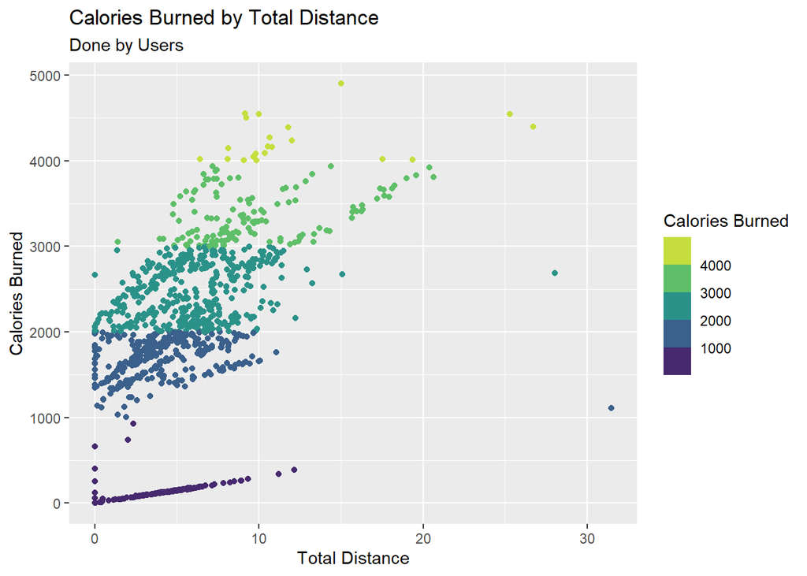

```r
ggplot(data = activity, aes(x = total_distance, y = calories_burned)) +
  geom_point(aes(color = calories_burned)) +
  scale_color_viridis_b(name = "Calories Burned") +
  labs(title = "Calories Burned by Total Distance", subtitle = "Done by Users",
       x = "Total Distance", y = "Calories Burned")
```

```r
ggsave("calories_burned_by_total_distance.png")
```

**Finding:** Strong indication of two different user base. 1. This user base is a power user who burns calories as intended by the distance taken. 2. This user base takes the most minimal distance to burn calories. However, these two segments are pretty disproportionate.

*Average Heart Rate by Total Number of Steps and Calories Burned*

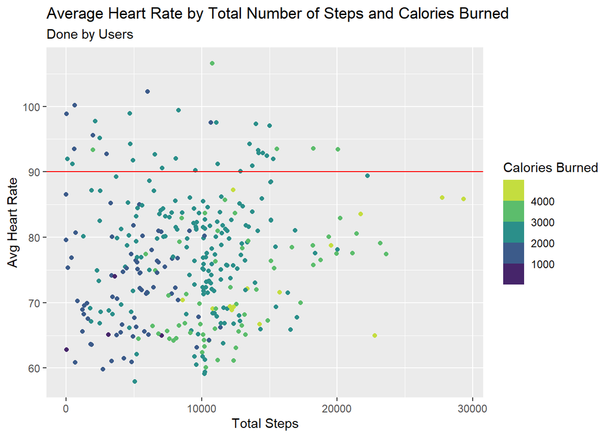

```r
heartrate %>%
  summarise(avg_heart_rate = mean(heart_rate)) %>%
  merge(activity, all = TRUE) %>%
  drop_na() %>%
  ggplot(aes(x = total_steps, y = avg_heart_rate)) +
  geom_point(aes(color = calories_burned)) +
  geom_hline(aes(yintercept = 90), color = "red") +
  scale_color_viridis_b(name = "Calories Burned") +
  labs(title = "Average Heart Rate by Total Number of Steps and Calories Burned",
       subtitle = "Done by Users", x = "Total Steps", y = "Avg Heart Rate")
```

```r
ggsave("avg_hear_rate_by_total_steps.png")
```

**Findings:** On average, most users’ heart rate is not intensely high (below 90) to burn large amounts of calories with many steps.

*Heart Rate of Users by the amount of Sleep*

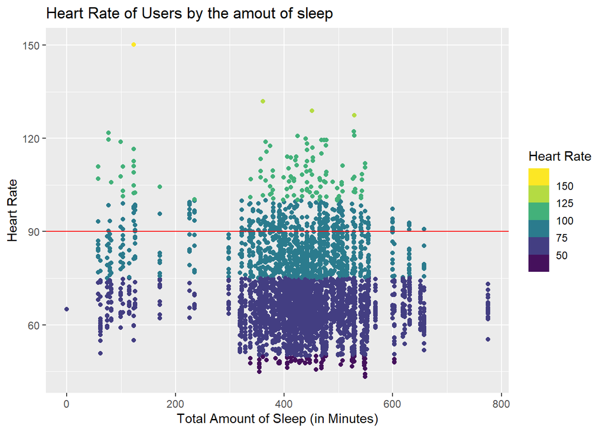

```r
heartrate %>%
  #summarise(avg_heart_rate = mean(heart_rate)) %>%
  # The above line could be added to look at the average heart rate
  merge(sleep, all = TRUE) %>%
  drop_na() %>%
  ggplot(aes(x = total_minutes_asleep, y = heart_rate)) +
  geom_point(aes(color = heart_rate)) +
  geom_hline(aes(yintercept = 90), color = "red") +
  scale_color_viridis_b(name = "Heart Rate") +
  labs(title = "Heart Rate of Users by the amout of sleep",
       x = "Total Amount of Sleep (in Minutes)", y = "Heart Rate")
```

```r
ggsave("heart_rate_by_sleep_amount.png")
```

**Finding:** Most people who track their sleep data generally have low heart rates as expected but have some outliers with heart rates unusually high, which could be false reading when a tracker is not equipped correctly.